# An Analysis of Fielding in Baseball

Currently, the metric that is looked at the most when considering fielding in baseball is fielding percentage. While the FP gives a generic overview of a player's ability to field balls, it is not a wholly reliable statistic to rate a player.

The first thing I wanted to consider when making my own test statistic was the lack of double plays, passed balls and wild pitches in the fielding percentage formula which is defined as:

$ (Putouts + Assists)/(Putouts + Assists + Errors)$

I believe that a fielder's participation in a double play, passed ball or a wild pitch should affect their fielding percentage. Naively, I wanted to just throw in the variables that I thought were missing into the formula, so it would look something like this:

$ (Putouts + Assists + Double Plays)/(Putouts + Assists + Errors + Passed Ball + Wild Pitch)$

```python
import numpy as np
import pandas as pd
import matplotlib.pylab as plt
```

```python
local_path = 'baseballdatabank-master/core/Fielding.csv'

df= pd.read_csv(local_path)

df.head()
```

|  | playerID | yearID | stint | teamID | lgID | POS | G | GS | InnOuts | PO | A | E | DP | PB | WP | SB | CS | ZR |
| --- | --- | --- | --- | --- | --- | --- | --- | --- | --- | --- | --- | --- | --- | --- | --- | --- | --- | --- |
| 0 | abercda01 | 1871 | 1 | TRO | NaN | SS | 1 | 1.0 | 24.0 | 1 | 3 | 2.0 | 0 | NaN | NaN | NaN | NaN | NaN |
| 1 | addybo01 | 1871 | 1 | RC1 | NaN | 2B | 22 | 22.0 | 606.0 | 67 | 72 | 42.0 | 5 | NaN | NaN | NaN | NaN | NaN |
| 2 | addybo01 | 1871 | 1 | RC1 | NaN | SS | 3 | 3.0 | 96.0 | 8 | 14 | 7.0 | 0 | NaN | NaN | NaN | NaN | NaN |
| 3 | allisar01 | 1871 | 1 | CL1 | NaN | 2B | 2 | 0.0 | 18.0 | 1 | 4 | 0.0 | 0 | NaN | NaN | NaN | NaN | NaN |
| 4 | allisar01 | 1871 | 1 | CL1 | NaN | OF | 29 | 29.0 | 729.0 | 51 | 3 | 7.0 | 1 | NaN | NaN | NaN | NaN | NaN |

```python
# Replace NaN values for PB, WP and DP
# dfClean= dfF.dropna(subset = ['DP', 'PB', 'WP'])

df.fillna(0,inplace=True)
df.head()
```

|  | playerID | yearID | stint | teamID | lgID | POS | G | GS | InnOuts | PO | A | E | DP | PB | WP | SB | CS | ZR |
| --- | --- | --- | --- | --- | --- | --- | --- | --- | --- | --- | --- | --- | --- | --- | --- | --- | --- | --- |
| 0 | abercda01 | 1871 | 1 | TRO | 0 | SS | 1 | 1.0 | 24.0 | 1 | 3 | 2.0 | 0 | 0.0 | 0.0 | 0.0 | 0.0 | 0.0 |
| 1 | addybo01 | 1871 | 1 | RC1 | 0 | 2B | 22 | 22.0 | 606.0 | 67 | 72 | 42.0 | 5 | 0.0 | 0.0 | 0.0 | 0.0 | 0.0 |
| 2 | addybo01 | 1871 | 1 | RC1 | 0 | SS | 3 | 3.0 | 96.0 | 8 | 14 | 7.0 | 0 | 0.0 | 0.0 | 0.0 | 0.0 | 0.0 |
| 3 | allisar01 | 1871 | 1 | CL1 | 0 | 2B | 2 | 0.0 | 18.0 | 1 | 4 | 0.0 | 0 | 0.0 | 0.0 | 0.0 | 0.0 | 0.0 |
| 4 | allisar01 | 1871 | 1 | CL1 | 0 | OF | 29 | 29.0 | 729.0 | 51 | 3 | 7.0 | 1 | 0.0 | 0.0 | 0.0 | 0.0 | 0.0 |

```python
# Calculate our regular FP and new FP
dfF = df.copy()
dfF.drop(['stint', 'teamID','lgID','InnOuts'], axis=1)
dfF['rFP'] = (dfF['PO'] + dfF['A']) / (dfF['PO'] + dfF['A'] + dfF['E'])
dfF['nFP'] = (dfF['PO'] + dfF['A'] + dfF['DP']) / (dfF['PO'] + dfF['A'] + dfF['E'] + dfF['PB'] + dfF['WP'])
dfF.head()
```

|  | playerID | yearID | stint | teamID | lgID | POS | G | GS | InnOuts | PO | A | E | DP | PB | WP | SB | CS | ZR | rFP | nFP |
| --- | --- | --- | --- | --- | --- | --- | --- | --- | --- | --- | --- | --- | --- | --- | --- | --- | --- | --- | --- | --- |
| 0 | abercda01 | 1871 | 1 | TRO | 0 | SS | 1 | 1.0 | 24.0 | 1 | 3 | 2.0 | 0 | 0.0 | 0.0 | 0.0 | 0.0 | 0.0 | 0.666667 | 0.666667 |
| 1 | addybo01 | 1871 | 1 | RC1 | 0 | 2B | 22 | 22.0 | 606.0 | 67 | 72 | 42.0 | 5 | 0.0 | 0.0 | 0.0 | 0.0 | 0.0 | 0.767956 | 0.795580 |
| 2 | addybo01 | 1871 | 1 | RC1 | 0 | SS | 3 | 3.0 | 96.0 | 8 | 14 | 7.0 | 0 | 0.0 | 0.0 | 0.0 | 0.0 | 0.0 | 0.758621 | 0.758621 |
| 3 | allisar01 | 1871 | 1 | CL1 | 0 | 2B | 2 | 0.0 | 18.0 | 1 | 4 | 0.0 | 0 | 0.0 | 0.0 | 0.0 | 0.0 | 0.0 | 1.000000 | 1.000000 |
| 4 | allisar01 | 1871 | 1 | CL1 | 0 | OF | 29 | 29.0 | 729.0 | 51 | 3 | 7.0 | 1 | 0.0 | 0.0 | 0.0 | 0.0 | 0.0 | 0.885246 | 0.901639 |

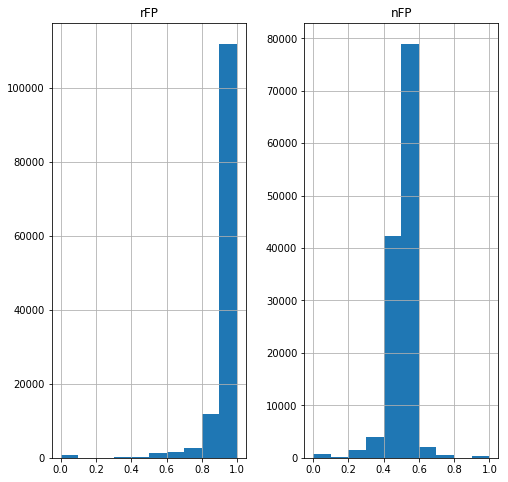

```python
# Initialize figure
fig, ax = plt.subplots(nrows=1, ncols=2, figsize=(8,8))


#Normalize the values
maxv = dfF['nFP'].max()
dfF['nFP'] = dfF['nFP']/maxv

# Plot histogram
dfF.hist(column="rFP", ax=ax[0]);
dfF.hist(column ="nFP", ax=ax[1]);
```

```
array([[<matplotlib.axes._subplots.AxesSubplot object at 0x000000FB1F53A6A0>]],
      dtype=object)
```

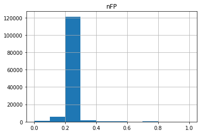

```python
weight = (dfF['DP']+1)/(dfF['PO']+1)
dfF['nFP'] = (dfF['PO'] + dfF['A'] + dfF['DP'] * weight) / (dfF['PO'] + dfF['A'] + dfF['E'] + dfF['PB'] + dfF['WP'])

#Normalize the values
maxv = dfF['nFP'].max()
dfF['nFP'] = dfF['nFP']/maxv

dfF.hist(column ="nFP")
```

Now let's see if the new stat has a better correlation with the win loss ratio than the old Fielding percentage.

```python
# Average nFP and rFP for teams sorted by year and team
df_P = dfF.groupby(['teamID', 'yearID'])[['nFP','rFP']].mean()

#Read in actual FP and Win/Loss ratio for the team from lahman - this is so we can compare
path = 'baseballdatabank-master/core/Teams.csv'

df_T= pd.read_csv(path)

df_T = df_T[['yearID', 'teamID', 'W', 'L', 'SB','CS','RA','SV','HA','BBA']]
df_T['W/L'] = df_T['W']/df_T['L']
df_T = df_T.groupby(['teamID', 'yearID'])[['W/L','SB','CS','RA','SV','HA','BBA']].mean()
df_T.head()
```

| teamID | yearID | W/L | SB | CS | RA | SV | HA | BBA |
| --- | --- | --- | --- | --- | --- | --- | --- | --- |
| ALT | 1884 | 0.315789 | NaN | NaN | 216 | 0 | 292 | 52 |
| ANA | 1997 | 1.076923 | 126.0 | 72.0 | 794 | 39 | 1506 | 605 |
|  | 1998 | 1.103896 | 93.0 | 45.0 | 783 | 52 | 1481 | 630 |
|  | 1999 | 0.760870 | 71.0 | 45.0 | 826 | 37 | 1472 | 624 |
|  | 2000 | 1.025000 | 93.0 | 52.0 | 869 | 46 | 1534 | 662 |

```python
df_Combined = df_T.copy()
df_Combined['nFP'] = df_P['nFP'].copy()
df_Combined['rFP'] = df_P['rFP'].copy()
df_Combined.head()
```

| teamID | yearID | W/L | SB | CS | RA | SV | HA | BBA | nFP | rFP |
| --- | --- | --- | --- | --- | --- | --- | --- | --- | --- | --- |
| ALT | 1884 | 0.315789 | NaN | NaN | 216 | 0 | 292 | 52 | 0.179934 | 0.754810 |
| ANA | 1997 | 1.076923 | 126.0 | 72.0 | 794 | 39 | 1506 | 605 | 0.249335 | 0.971577 |
|  | 1998 | 1.103896 | 93.0 | 45.0 | 783 | 52 | 1481 | 630 | 0.254171 | 0.970734 |
|  | 1999 | 0.760870 | 71.0 | 45.0 | 826 | 37 | 1472 | 624 | 0.254373 | 0.971768 |
|  | 2000 | 1.025000 | 93.0 | 52.0 | 869 | 46 | 1534 | 662 | 0.254475 | 0.963988 |

```python
df_Combined.corr(method='pearson')
```

|  | W/L | SB | CS | RA | SV | HA | BBA | nFP | rFP |
| --- | --- | --- | --- | --- | --- | --- | --- | --- | --- |
| W/L | 1.000000 | 0.153882 | -0.011888 | -0.413108 | 0.083303 | -0.234356 | -0.217692 | 0.015665 | 0.037848 |
| SB | 0.153882 | 1.000000 | 0.644230 | 0.040905 | -0.271556 | -0.130097 | -0.173663 | -0.368654 | -0.339254 |
| CS | -0.011888 | 0.644230 | 1.000000 | 0.027080 | -0.107576 | 0.188438 | 0.070636 | 0.079392 | 0.125619 |
| RA | -0.413108 | 0.040905 | 0.027080 | 1.000000 | 0.161947 | 0.806719 | 0.647580 | 0.276360 | 0.263281 |
| SV | 0.083303 | -0.271556 | -0.107576 | 0.161947 | 1.000000 | 0.387293 | 0.461095 | 0.617438 | 0.591305 |
| HA | -0.234356 | -0.130097 | 0.188438 | 0.806719 | 0.387293 | 1.000000 | 0.746575 | 0.645799 | 0.658253 |
| BBA | -0.217692 | -0.173663 | 0.070636 | 0.647580 | 0.461095 | 0.746575 | 1.000000 | 0.656446 | 0.658598 |
| nFP | 0.015665 | -0.368654 | 0.079392 | 0.276360 | 0.617438 | 0.645799 | 0.656446 | 1.000000 | 0.944212 |
| rFP | 0.037848 | -0.339254 | 0.125619 | 0.263281 | 0.591305 | 0.658253 | 0.658598 | 0.944212 | 1.000000 |

- Based off of correlation, our version of the FP (nFP) performs about the same, if not worse in certain areas than rFP.

## Does Position Matter?

- We've looked at double plays and wild pitches, but we haven't really considered the position of the fielder when they make plays. A fielder throwing an out from the outfield to first base is a whole lot harder than the pitcher throwing an out at first base. By looking at the players FP at a certain position and comparing that to the league average, we can get an idea of the fielder's range.

```python
df_Position = df.copy()
df_Position.drop(['stint','lgID','InnOuts'], axis=1)
df_Position['FP'] = (df_Position['PO'] + df_Position['A']) / (df_Position['PO'] + df_Position['A'] + df_Position['E'])
df_Position.head()
```

|  | playerID | yearID | stint | teamID | lgID | POS | G | GS | InnOuts | PO | A | E | DP | PB | WP | SB | CS | ZR | FP |
| --- | --- | --- | --- | --- | --- | --- | --- | --- | --- | --- | --- | --- | --- | --- | --- | --- | --- | --- | --- |
| 0 | abercda01 | 1871 | 1 | TRO | 0 | SS | 1 | 1.0 | 24.0 | 1 | 3 | 2.0 | 0 | 0.0 | 0.0 | 0.0 | 0.0 | 0.0 | 0.666667 |
| 1 | addybo01 | 1871 | 1 | RC1 | 0 | 2B | 22 | 22.0 | 606.0 | 67 | 72 | 42.0 | 5 | 0.0 | 0.0 | 0.0 | 0.0 | 0.0 | 0.767956 |
| 2 | addybo01 | 1871 | 1 | RC1 | 0 | SS | 3 | 3.0 | 96.0 | 8 | 14 | 7.0 | 0 | 0.0 | 0.0 | 0.0 | 0.0 | 0.0 | 0.758621 |
| 3 | allisar01 | 1871 | 1 | CL1 | 0 | 2B | 2 | 0.0 | 18.0 | 1 | 4 | 0.0 | 0 | 0.0 | 0.0 | 0.0 | 0.0 | 0.0 | 1.000000 |
| 4 | allisar01 | 1871 | 1 | CL1 | 0 | OF | 29 | 29.0 | 729.0 | 51 | 3 | 7.0 | 1 | 0.0 | 0.0 | 0.0 | 0.0 | 0.0 | 0.885246 |

To get an idea of how fielding percentage changed over time, we can plot it over the years we have data for.

```python
# Average fielding percentage per year
FP_grouped = df_Position.groupby(['yearID'])[['PO','A','E','DP','PB','WP','FP']].mean()
FP_grouped.head()
```

| yearID | PO | A | E | DP | PB | WP | FP |
| --- | --- | --- | --- | --- | --- | --- | --- |
| 1871 | 29.735683 | 12.907489 | 8.519824 | 1.484581 | 2.158590 | 0.0 | 0.784575 |
| 1872 | 33.527211 | 14.350340 | 9.326531 | 1.595238 | 0.982993 | 0.0 | 0.758178 |
| 1873 | 40.581132 | 18.332075 | 12.041509 | 2.279245 | 1.562264 | 0.0 | 0.773082 |
| 1874 | 48.111538 | 21.150000 | 14.519231 | 2.061538 | 1.380769 | 0.0 | 0.739253 |
| 1875 | 39.766595 | 17.925054 | 10.282655 | 1.807281 | 1.747323 | 0.0 | 0.767979 |

```
Text(0.5,1,'Fielding Percentage Average Per Year')
```

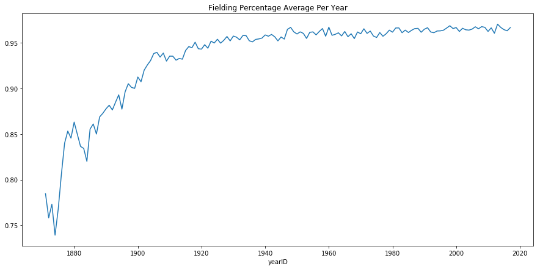

```python
fig, ax = plt.subplots(figsize=(15,7))
df_Position.groupby(['yearID']).mean()['FP'].plot(ax=ax)
ax.set_title('Fielding Percentage Average Per Year')
```

We can also investigate fielding percentage by position and see , historically, how the fielding is different or similar on a position by position basis.

```
Text(0.5,1,'Fielding Percentage Average Per Position')
```

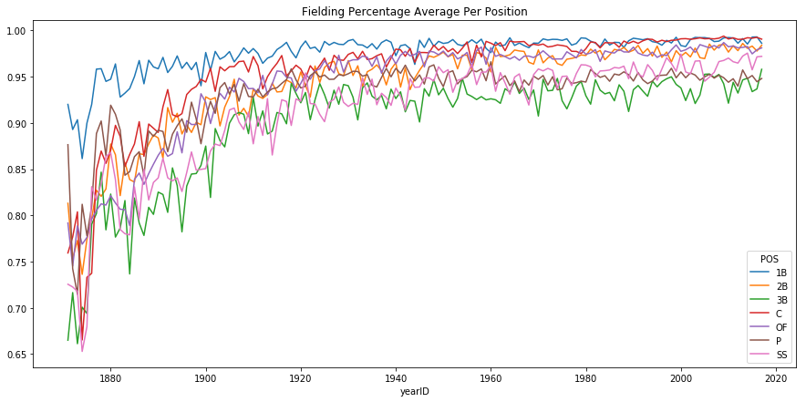

```python
# Average FP per position per year

fig, ax = plt.subplots(figsize=(15,7))
df_Position.groupby(['yearID','POS']).mean()['FP'].unstack().plot(ax=ax)
ax.set_title('Fielding Percentage Average Per Position')
```

- Looking at the graph we can see that the FP varies among each position and follows a trend. This gives us concrete evidence that it would not be accurate to compare two different fielding positions under one fielding position statistic.

By subtracting the average fielding percentage for each position from the average fielding percentage overall (in the same year), we get the expected range factor for each position. On an individual level, we can compare the individuals range factor to the overall range factor and see whether or not a player is fielding well.

$$ Expected RF = (Average FP Overall - Average FP (Position))^2 $$

```python
grouped = df_Position.groupby(['yearID','POS'])[['PO','A','E','DP','PB','WP','FP']].mean()

# print(FP_grouped['FP'])

#This gives us ERF for every position for every year
grouped['ERF'] = (FP_grouped['FP'] - grouped['FP']) **2

dfRF = df.copy()
dfRF['FP'] = (dfRF['PO'] + dfRF['A']) / (dfRF['PO'] + dfRF['A'] + dfRF['E'])

last = grouped['FP'].unstack('POS').tail(10)
```

[output not shown]

[output cut: 48 more lines]

```python
dfSS = dfRF.loc[ (dfRF['POS']=='SS') & (dfRF['yearID'] == 2015)]
dfSS['CRF'] = (dfSS['FP'] -  0.964279)**2

dfOF = dfRF.loc[(dfRF['POS']=='OF')  & (dfRF['yearID'] == 2015)]
dfOF['CRF'] = (dfOF['FP'] -  0.964279)**2

df1B = dfRF.loc[(dfRF['POS']=='1B')  & (dfRF['yearID'] == 2015)]
df1B['CRF'] = (df1B['FP'] -  0.964279)**2

df2B = dfRF.loc[(dfRF['POS']=='2B') & (dfRF['yearID'] == 2015)]
df2B['CRF'] = (df2B['FP'] -  0.964279)**2

df3B = dfRF.loc[(dfRF['POS']=='3B') & (dfRF['yearID'] == 2015)]
df3B['CRF'] = (df3B['FP'] -  0.964279)**2

dfC = dfRF.loc[(dfRF['POS']=='C') & (dfRF['yearID'] == 2015)]
dfC['CRF'] = (dfC['FP'] -  0.964279)**2

dfP = dfRF.loc[(dfRF['POS']=='P') & (dfRF['yearID'] == 2015)]
dfP['CRF'] = (dfP['FP'] -  0.964279)**2

df1B.head()
```

|  | playerID | yearID | stint | teamID | lgID | POS | G | GS | InnOuts | PO | A | E | DP | PB | WP | SB | CS | ZR | FP | CRF |
| --- | --- | --- | --- | --- | --- | --- | --- | --- | --- | --- | --- | --- | --- | --- | --- | --- | --- | --- | --- | --- |
| 132952 | abreujo02 | 2015 | 1 | CHA | AL | 1B | 115 | 115.0 | 3051.0 | 952 | 60 | 11.0 | 100 | 0.0 | 0.0 | 0.0 | 0.0 | 0.0 | 0.989247 | 0.000623 |
| 132956 | ackledu01 | 2015 | 2 | NYA | AL | 1B | 4 | 3.0 | 81.0 | 28 | 2 | 0.0 | 0 | 0.0 | 0.0 | 0.0 | 0.0 | 0.0 | 1.000000 | 0.001276 |
| 132962 | adamsma01 | 2015 | 1 | SLN | NL | 1B | 46 | 42.0 | 1056.0 | 321 | 32 | 3.0 | 30 | 0.0 | 0.0 | 0.0 | 0.0 | 0.0 | 0.991573 | 0.000745 |
| 132964 | adriaeh01 | 2015 | 1 | SFN | NL | 1B | 1 | 1.0 | 27.0 | 5 | 0 | 0.0 | 0 | 0.0 | 0.0 | 0.0 | 0.0 | 0.0 | 1.000000 | 0.001276 |
| 132969 | aguilje01 | 2015 | 1 | CLE | AL | 1B | 4 | 4.0 | 108.0 | 26 | 3 | 0.0 | 1 | 0.0 | 0.0 | 0.0 | 0.0 | 0.0 | 1.000000 | 0.001276 |

Now we have the calculated range factor for every player based on position in 2015. The next step is to compare this with the average expected range factor to see how well the player is fielding.

```python
grouped['ERF'][2015]
```

```
POS
1B    0.000817
2B    0.000353
3B    0.000926
C     0.000750
OF    0.000109
P     0.000170
SS    0.000047
Name: ERF, dtype: float64
```

```python
dfSS['Performance'] = dfSS['CRF'] - 0.000047
df1B['Performance'] = df1B['CRF'] - 0.000817
df2B['Performance'] = df2B['CRF'] - 0.000353
df3B['Performance'] = df3B['CRF'] - 0.000926
dfC['Performance'] = dfC['CRF'] - 0.000750
dfOF['Performance'] = dfOF['CRF'] - 0.000109
dfP['Performance'] = dfP['CRF'] - 0.000170
```

```
Text(0.5,1,'2B')
```

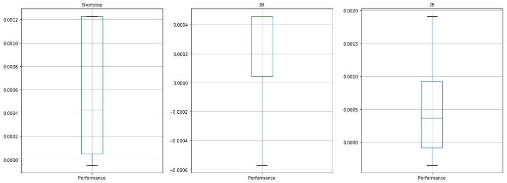

```python
fig, ax = plt.subplots(nrows=1, ncols=3,figsize=(20,7))

dfSS.boxplot(column='Performance',ax=ax[0],showfliers=False)
df1B.boxplot(column='Performance',ax=ax[1],showfliers=False)
df2B.boxplot(column='Performance',ax=ax[2],showfliers=False)

ax[0].set_title("Shortstop", fontsize=10)
ax[1].set_title("1B", fontsize=10)
ax[2].set_title("2B", fontsize=10)
```

```
Text(0.5,1,'C')
```

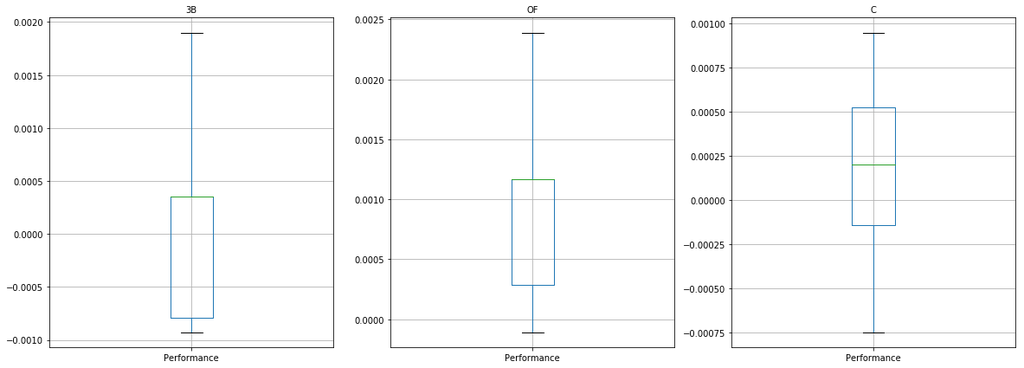

```python
fig, ax = plt.subplots(nrows=1, ncols=3,figsize=(20,7))

df3B.boxplot(column='Performance',ax=ax[0],showfliers=False)
dfOF.boxplot(column='Performance',ax=ax[1],showfliers=False)
dfC.boxplot(column='Performance',ax=ax[2],showfliers=False)
ax[0].set_title("3B", fontsize=10)
ax[1].set_title("OF", fontsize=10)
ax[2].set_title("C", fontsize=10)
```

```python
dfSS = dfSS.drop(['yearID','PB','WP','SB','CS','ZR'], axis=1)
dfSS.corr()
```

|  | stint | G | GS | InnOuts | PO | A | E | DP | FP | CRF | Performance |
| --- | --- | --- | --- | --- | --- | --- | --- | --- | --- | --- | --- |
| stint | 1.000000 | -0.096577 | -0.087819 | -0.090523 | -0.091559 | -0.079621 | -0.115914 | -0.078840 | -0.137921 | 0.033175 | 0.033175 |
| G | -0.096577 | 1.000000 | 0.995503 | 0.997040 | 0.987218 | 0.990831 | 0.854222 | 0.972230 | 0.129492 | -0.094909 | -0.094909 |
| GS | -0.087819 | 0.995503 | 1.000000 | 0.999587 | 0.989402 | 0.992701 | 0.854088 | 0.976423 | 0.128848 | -0.093350 | -0.093350 |
| InnOuts | -0.090523 | 0.997040 | 0.999587 | 1.000000 | 0.989452 | 0.993820 | 0.854960 | 0.976490 | 0.128405 | -0.093452 | -0.093452 |
| PO | -0.091559 | 0.987218 | 0.989402 | 0.989452 | 1.000000 | 0.986022 | 0.861228 | 0.979495 | 0.125698 | -0.091667 | -0.091667 |
| A | -0.079621 | 0.990831 | 0.992701 | 0.993820 | 0.986022 | 1.000000 | 0.853315 | 0.987306 | 0.128587 | -0.093870 | -0.093870 |
| E | -0.115914 | 0.854222 | 0.854088 | 0.854960 | 0.861228 | 0.853315 | 1.000000 | 0.846692 | 0.033738 | -0.068877 | -0.068877 |
| DP | -0.078840 | 0.972230 | 0.976423 | 0.976490 | 0.979495 | 0.987306 | 0.846692 | 1.000000 | 0.123164 | -0.090581 | -0.090581 |
| FP | -0.137921 | 0.129492 | 0.128848 | 0.128405 | 0.125698 | 0.128587 | 0.033738 | 0.123164 | 1.000000 | -0.910425 | -0.910425 |
| CRF | 0.033175 | -0.094909 | -0.093350 | -0.093452 | -0.091667 | -0.093870 | -0.068877 | -0.090581 | -0.910425 | 1.000000 | 1.000000 |
| Performance | 0.033175 | -0.094909 | -0.093350 | -0.093452 | -0.091667 | -0.093870 | -0.068877 | -0.090581 | -0.910425 | 1.000000 | 1.000000 |

```python
df1B = df1B.drop(['yearID','PB','WP','SB','CS','ZR'], axis=1)
df1B.corr()
```

|  | stint | G | GS | InnOuts | PO | A | E | DP | FP | CRF | Performance |
| --- | --- | --- | --- | --- | --- | --- | --- | --- | --- | --- | --- |
| stint | 1.000000 | -0.157856 | -0.154940 | -0.157422 | -0.158232 | -0.150256 | -0.122534 | -0.150050 | -0.074103 | -0.022235 | -0.022235 |
| G | -0.157856 | 1.000000 | 0.981169 | 0.989296 | 0.990506 | 0.959783 | 0.751706 | 0.980434 | 0.035120 | -0.076484 | -0.076484 |
| GS | -0.154940 | 0.981169 | 1.000000 | 0.997702 | 0.995866 | 0.976391 | 0.759369 | 0.980777 | 0.030083 | -0.071566 | -0.071566 |
| InnOuts | -0.157422 | 0.989296 | 0.997702 | 1.000000 | 0.998290 | 0.977479 | 0.742717 | 0.984289 | 0.034241 | -0.070812 | -0.070812 |
| PO | -0.158232 | 0.990506 | 0.995866 | 0.998290 | 1.000000 | 0.975031 | 0.746980 | 0.985587 | 0.035688 | -0.070433 | -0.070433 |
| A | -0.150256 | 0.959783 | 0.976391 | 0.977479 | 0.975031 | 1.000000 | 0.732925 | 0.957166 | 0.033753 | -0.066362 | -0.066362 |
| E | -0.122534 | 0.751706 | 0.759369 | 0.742717 | 0.746980 | 0.732925 | 1.000000 | 0.743222 | -0.145243 | -0.064207 | -0.064207 |
| DP | -0.150050 | 0.980434 | 0.980777 | 0.984289 | 0.985587 | 0.957166 | 0.743222 | 1.000000 | 0.034929 | -0.071230 | -0.071230 |
| FP | -0.074103 | 0.035120 | 0.030083 | 0.034241 | 0.035688 | 0.033753 | -0.145243 | 0.034929 | 1.000000 | -0.788691 | -0.788691 |
| CRF | -0.022235 | -0.076484 | -0.071566 | -0.070812 | -0.070433 | -0.066362 | -0.064207 | -0.071230 | -0.788691 | 1.000000 | 1.000000 |
| Performance | -0.022235 | -0.076484 | -0.071566 | -0.070812 | -0.070433 | -0.066362 | -0.064207 | -0.071230 | -0.788691 | 1.000000 | 1.000000 |

```python
df2B = df2B.drop(['yearID','PB','WP','SB','CS','ZR'], axis=1)
df2B.corr()
```

|  | stint | G | GS | InnOuts | PO | A | E | DP | FP | CRF | Performance |
| --- | --- | --- | --- | --- | --- | --- | --- | --- | --- | --- | --- |
| stint | 1.000000 | -0.113468 | -0.104686 | -0.107914 | -0.110215 | -0.111272 | -0.089359 | -0.112875 | -0.012241 | -0.080509 | -0.080509 |
| G | -0.113468 | 1.000000 | 0.995347 | 0.997007 | 0.984086 | 0.992972 | 0.847033 | 0.972359 | 0.034489 | -0.223880 | -0.223880 |
| GS | -0.104686 | 0.995347 | 1.000000 | 0.999410 | 0.989725 | 0.994965 | 0.843005 | 0.974419 | 0.044198 | -0.210239 | -0.210239 |
| InnOuts | -0.107914 | 0.997007 | 0.999410 | 1.000000 | 0.990185 | 0.995749 | 0.844751 | 0.976026 | 0.044835 | -0.211435 | -0.211435 |
| PO | -0.110215 | 0.984086 | 0.989725 | 0.990185 | 1.000000 | 0.990081 | 0.845666 | 0.987377 | 0.044531 | -0.202028 | -0.202028 |
| A | -0.111272 | 0.992972 | 0.994965 | 0.995749 | 0.990081 | 1.000000 | 0.840435 | 0.983895 | 0.052323 | -0.210477 | -0.210477 |
| E | -0.089359 | 0.847033 | 0.843005 | 0.844751 | 0.845666 | 0.840435 | 1.000000 | 0.839501 | -0.188171 | -0.239217 | -0.239217 |
| DP | -0.112875 | 0.972359 | 0.974419 | 0.976026 | 0.987377 | 0.983895 | 0.839501 | 1.000000 | 0.049019 | -0.196451 | -0.196451 |
| FP | -0.012241 | 0.034489 | 0.044198 | 0.044835 | 0.044531 | 0.052323 | -0.188171 | 0.049019 | 1.000000 | -0.474273 | -0.474273 |
| CRF | -0.080509 | -0.223880 | -0.210239 | -0.211435 | -0.202028 | -0.210477 | -0.239217 | -0.196451 | -0.474273 | 1.000000 | 1.000000 |
| Performance | -0.080509 | -0.223880 | -0.210239 | -0.211435 | -0.202028 | -0.210477 | -0.239217 | -0.196451 | -0.474273 | 1.000000 | 1.000000 |

```python
df3B = df3B.drop(['yearID','PB','WP','SB','CS','ZR'], axis=1)
df3B.corr()
```

|  | stint | G | GS | InnOuts | PO | A | E | DP | FP | CRF | Performance |
| --- | --- | --- | --- | --- | --- | --- | --- | --- | --- | --- | --- |
| stint | 1.000000 | -0.059997 | -0.057796 | -0.058780 | -0.073171 | -0.059655 | -0.073020 | -0.070860 | 0.010068 | -0.004396 | -0.004396 |
| G | -0.059997 | 1.000000 | 0.989927 | 0.993463 | 0.967678 | 0.981397 | 0.912998 | 0.943726 | 0.131950 | -0.127181 | -0.127181 |
| GS | -0.057796 | 0.989927 | 1.000000 | 0.998843 | 0.975434 | 0.984720 | 0.922278 | 0.950894 | 0.122392 | -0.117041 | -0.117041 |
| InnOuts | -0.058780 | 0.993463 | 0.998843 | 1.000000 | 0.977509 | 0.988039 | 0.922256 | 0.953311 | 0.125815 | -0.119196 | -0.119196 |
| PO | -0.073171 | 0.967678 | 0.975434 | 0.977509 | 1.000000 | 0.973454 | 0.919195 | 0.952931 | 0.119853 | -0.114049 | -0.114049 |
| A | -0.059655 | 0.981397 | 0.984720 | 0.988039 | 0.973454 | 1.000000 | 0.918858 | 0.972367 | 0.130429 | -0.118153 | -0.118153 |
| E | -0.073020 | 0.912998 | 0.922278 | 0.922256 | 0.919195 | 0.918858 | 1.000000 | 0.880084 | 0.001275 | -0.068856 | -0.068856 |
| DP | -0.070860 | 0.943726 | 0.950894 | 0.953311 | 0.952931 | 0.972367 | 0.880084 | 1.000000 | 0.118546 | -0.109583 | -0.109583 |
| FP | 0.010068 | 0.131950 | 0.122392 | 0.125815 | 0.119853 | 0.130429 | 0.001275 | 0.118546 | 1.000000 | -0.879477 | -0.879477 |
| CRF | -0.004396 | -0.127181 | -0.117041 | -0.119196 | -0.114049 | -0.118153 | -0.068856 | -0.109583 | -0.879477 | 1.000000 | 1.000000 |
| Performance | -0.004396 | -0.127181 | -0.117041 | -0.119196 | -0.114049 | -0.118153 | -0.068856 | -0.109583 | -0.879477 | 1.000000 | 1.000000 |

While the statistic does give an idea of how well the player fields compared to the average, I do not think we can use the stat as a way to predict in game stats like assists and errors.

```python
dfJoin = dfF.loc[(df['yearID']==2015) & (df['POS']=='SS')]
dftoJoin = dfSS[['playerID','CRF','Performance']].copy()

dfJoined = pd.merge(dfJoin, dftoJoin, on=['playerID'])
dfJoined.head(100)
```

|  | playerID | yearID | stint | teamID | lgID | POS | G | GS | InnOuts | PO | ... | DP | PB | WP | SB | CS | ZR | rFP | nFP | CRF | Performance |
| --- | --- | --- | --- | --- | --- | --- | --- | --- | --- | --- | --- | --- | --- | --- | --- | --- | --- | --- | --- | --- | --- |
| 0 | adamecr01 | 2015 | 1 | COL | NL | SS | 13 | 11.0 | 279.0 | 15 | ... | 8 | 0.0 | 0.0 | 0.0 | 0.0 | 0.0 | 0.957447 | 0.263298 | 4.667884e-05 | -3.211595e-07 |
| 1 | adriaeh01 | 2015 | 1 | SFN | NL | SS | 20 | 16.0 | 455.0 | 24 | ... | 13 | 0.0 | 0.0 | 0.0 | 0.0 | 0.0 | 0.987342 | 0.269873 | 5.318915e-04 | 4.848915e-04 |
| 2 | ahmedni01 | 2015 | 1 | ARI | NL | SS | 129 | 116.0 | 3127.0 | 190 | ... | 84 | 0.0 | 0.0 | 0.0 | 0.0 | 0.0 | 0.977233 | 0.260675 | 1.678042e-04 | 1.208042e-04 |
| 3 | alberha01 | 2015 | 1 | TEX | AL | SS | 8 | 3.0 | 102.0 | 4 | ... | 3 | 0.0 | 0.0 | 0.0 | 0.0 | 0.0 | 1.000000 | 0.285294 | 1.275990e-03 | 1.228990e-03 |
| 4 | amarial01 | 2015 | 1 | SDN | NL | SS | 85 | 79.0 | 2014.0 | 121 | ... | 52 | 0.0 | 0.0 | 0.0 | 0.0 | 0.0 | 0.966102 | 0.257479 | 3.322217e-06 | -4.367778e-05 |
| 5 | andruel01 | 2015 | 1 | TEX | AL | SS | 160 | 159.0 | 4214.0 | 248 | ... | 114 | 0.0 | 0.0 | 0.0 | 0.0 | 0.0 | 0.972010 | 0.259749 | 5.977112e-05 | 1.277112e-05 |
| 6 | ariasjo01 | 2015 | 1 | SFN | NL | SS | 8 | 6.0 | 144.0 | 4 | ... | 2 | 0.0 | 0.0 | 0.0 | 0.0 | 0.0 | 0.882353 | 0.229412 | 6.711879e-03 | 6.664879e-03 |
| 7 | avilemi01 | 2015 | 1 | CLE | AL | SS | 23 | 20.0 | 516.0 | 19 | ... | 10 | 0.0 | 0.0 | 0.0 | 0.0 | 0.0 | 0.959459 | 0.258446 | 2.322797e-05 | -2.377203e-05 |
| 8 | aybarer01 | 2015 | 1 | LAA | AL | SS | 154 | 154.0 | 4007.0 | 244 | ... | 71 | 0.0 | 0.0 | 0.0 | 0.0 | 0.0 | 0.972581 | 0.251559 | 6.891731e-05 | 2.191731e-05 |
| 9 | baezja01 | 2015 | 1 | CHN | NL | SS | 8 | 5.0 | 135.0 | 7 | ... | 3 | 0.0 | 0.0 | 0.0 | 0.0 | 0.0 | 1.000000 | 0.267857 | 1.275990e-03 | 1.228990e-03 |
| 10 | barmecl01 | 2015 | 1 | SDN | NL | SS | 89 | 51.0 | 1528.0 | 87 | ... | 28 | 0.0 | 0.0 | 0.0 | 0.0 | 0.0 | 0.969466 | 0.251171 | 2.690133e-05 | -2.009867e-05 |
| 11 | barneda01 | 2015 | 1 | LAN | NL | SS | 1 | 1.0 | 21.0 | 0 | ... | 0 | 0.0 | 0.0 | 0.0 | 0.0 | 0.0 | 1.000000 | 0.250000 | 1.275990e-03 | 1.228990e-03 |
| 12 | beckhgo01 | 2015 | 1 | CHA | AL | SS | 5 | 4.0 | 105.0 | 9 | ... | 6 | 0.0 | 0.0 | 0.0 | 0.0 | 0.0 | 0.956522 | 0.284783 | 6.017510e-05 | 1.317510e-05 |
| 13 | beckhti01 | 2015 | 1 | TBA | AL | SS | 28 | 22.0 | 623.0 | 23 | ... | 10 | 0.0 | 0.0 | 0.0 | 0.0 | 0.0 | 0.974026 | 0.258387 | 9.500350e-05 | 4.800350e-05 |
| 14 | biancje01 | 2015 | 1 | BOS | AL | SS | 1 | 0.0 | 3.0 | 1 | ... | 1 | 0.0 | 0.0 | 0.0 | 0.0 | 0.0 | 1.000000 | 0.375000 | 1.275990e-03 | 1.228990e-03 |
| 15 | blancan01 | 2015 | 1 | PHI | NL | SS | 10 | 7.0 | 195.0 | 8 | ... | 4 | 0.0 | 0.0 | 0.0 | 0.0 | 0.0 | 0.968750 | 0.259549 | 1.998984e-05 | -2.701016e-05 |
| 16 | bloomwi01 | 2015 | 1 | SEA | AL | SS | 7 | 5.0 | 117.0 | 6 | ... | 1 | 0.0 | 0.0 | 0.0 | 0.0 | 0.0 | 1.000000 | 0.253571 | 1.275990e-03 | 1.228990e-03 |
| 17 | bogaexa01 | 2015 | 1 | BOS | AL | SS | 156 | 154.0 | 4081.0 | 236 | ... | 95 | 0.0 | 0.0 | 0.0 | 0.0 | 0.0 | 0.983728 | 0.260163 | 3.782562e-04 | 3.312562e-04 |
| 18 | cabreas01 | 2015 | 1 | TBA | AL | SS | 136 | 131.0 | 3423.0 | 150 | ... | 51 | 0.0 | 0.0 | 0.0 | 0.0 | 0.0 | 0.979684 | 0.254832 | 2.373132e-04 | 1.903132e-04 |
| 19 | cabreev01 | 2015 | 1 | BAL | AL | SS | 27 | 26.0 | 673.0 | 22 | ... | 9 | 0.0 | 0.0 | 0.0 | 0.0 | 0.0 | 0.965517 | 0.252624 | 1.533242e-06 | -4.546676e-05 |
| 20 | calixor01 | 2015 | 1 | KCA | AL | SS | 1 | 0.0 | 12.0 | 0 | ... | 0 | 0.0 | 0.0 | 0.0 | 0.0 | 0.0 | 1.000000 | 0.250000 | 1.275990e-03 | 1.228990e-03 |
| 21 | castrda01 | 2015 | 1 | ATL | NL | SS | 10 | 8.0 | 231.0 | 12 | ... | 10 | 0.0 | 0.0 | 0.0 | 0.0 | 0.0 | 1.000000 | 0.310440 | 1.275990e-03 | 1.228990e-03 |
| 22 | castrst01 | 2015 | 1 | CHN | NL | SS | 109 | 104.0 | 2829.0 | 143 | ... | 58 | 0.0 | 0.0 | 0.0 | 0.0 | 0.0 | 0.962810 | 0.252977 | 2.158204e-06 | -4.484180e-05 |
| 23 | ciriape01 | 2015 | 1 | ATL | NL | SS | 9 | 9.0 | 207.0 | 12 | ... | 5 | 0.0 | 0.0 | 0.0 | 0.0 | 0.0 | 1.000000 | 0.267483 | 1.275990e-03 | 1.228990e-03 |
| 24 | colonch01 | 2015 | 1 | KCA | AL | SS | 21 | 14.0 | 424.0 | 20 | ... | 9 | 0.0 | 0.0 | 0.0 | 0.0 | 0.0 | 0.957143 | 0.254592 | 5.092453e-05 | 3.924535e-06 |
| 25 | correca01 | 2015 | 1 | HOU | AL | SS | 99 | 99.0 | 2612.0 | 112 | ... | 41 | 0.0 | 0.0 | 0.0 | 0.0 | 0.0 | 0.966667 | 0.251435 | 5.700952e-06 | -4.129905e-05 |
| 26 | cozarza01 | 2015 | 1 | CIN | NL | SS | 52 | 52.0 | 1349.0 | 79 | ... | 30 | 0.0 | 0.0 | 0.0 | 0.0 | 0.0 | 0.985981 | 0.260076 | 4.709902e-04 | 4.239902e-04 |
| 27 | crawfbr01 | 2015 | 1 | SFN | NL | SS | 140 | 136.0 | 3601.0 | 191 | ... | 89 | 0.0 | 0.0 | 0.0 | 0.0 | 0.0 | 0.979398 | 0.261378 | 2.285775e-04 | 1.815775e-04 |
| 28 | darnach01 | 2015 | 1 | PHI | NL | SS | 3 | 2.0 | 64.0 | 3 | ... | 1 | 0.0 | 0.0 | 0.0 | 0.0 | 0.0 | 1.000000 | 0.262500 | 1.275990e-03 | 1.228990e-03 |
| 29 | dejesiv02 | 2015 | 1 | CIN | NL | SS | 10 | 8.0 | 241.0 | 15 | ... | 6 | 0.0 | 0.0 | 0.0 | 0.0 | 0.0 | 0.928571 | 0.247768 | 1.275031e-03 | 1.228031e-03 |
| ... | ... | ... | ... | ... | ... | ... | ... | ... | ... | ... | ... | ... | ... | ... | ... | ... | ... | ... | ... | ... | ... |
| 70 | lowrije01 | 2015 | 1 | HOU | AL | SS | 17 | 16.0 | 459.0 | 21 | ... | 6 | 0.0 | 0.0 | 0.0 | 0.0 | 0.0 | 1.000000 | 0.256450 | 1.275990e-03 | 1.228990e-03 |
| 71 | machadi01 | 2015 | 1 | DET | AL | SS | 24 | 20.0 | 539.0 | 37 | ... | 14 | 0.0 | 0.0 | 0.0 | 0.0 | 0.0 | 0.978947 | 0.259280 | 2.151610e-04 | 1.681610e-04 |
| 72 | machama01 | 2015 | 1 | BAL | AL | SS | 7 | 6.0 | 159.0 | 4 | ... | 3 | 0.0 | 0.0 | 0.0 | 0.0 | 0.0 | 0.904762 | 0.254762 | 3.542285e-03 | 3.495285e-03 |
| 73 | marrede01 | 2015 | 1 | BOS | AL | SS | 6 | 1.0 | 51.0 | 3 | ... | 2 | 0.0 | 0.0 | 0.0 | 0.0 | 0.0 | 1.000000 | 0.291667 | 1.275990e-03 | 1.228990e-03 |
| 74 | marteke01 | 2015 | 1 | SEA | AL | SS | 51 | 49.0 | 1321.0 | 64 | ... | 31 | 0.0 | 0.0 | 0.0 | 0.0 | 0.0 | 0.959641 | 0.257020 | 2.150867e-05 | -2.549133e-05 |
| 75 | mercejo03 | 2015 | 1 | PIT | NL | SS | 115 | 108.0 | 2959.0 | 148 | ... | 78 | 0.0 | 0.0 | 0.0 | 0.0 | 0.0 | 0.986166 | 0.266974 | 4.790411e-04 | 4.320411e-04 |
| 76 | middlwi01 | 2015 | 1 | SDN | NL | SS | 8 | 4.0 | 117.0 | 5 | ... | 3 | 0.0 | 0.0 | 0.0 | 0.0 | 0.0 | 1.000000 | 0.281250 | 1.275990e-03 | 1.228990e-03 |
| 77 | millebr02 | 2015 | 1 | SEA | AL | SS | 89 | 83.0 | 2251.0 | 109 | ... | 56 | 0.0 | 0.0 | 0.0 | 0.0 | 0.0 | 0.964286 | 0.259578 | 4.508163e-11 | -4.699995e-05 |
| 78 | negrokr01 | 2015 | 1 | CIN | NL | SS | 10 | 7.0 | 243.0 | 11 | ... | 7 | 0.0 | 0.0 | 0.0 | 0.0 | 0.0 | 0.976744 | 0.271318 | 1.553809e-04 | 1.083809e-04 |
| 79 | noonani01 | 2015 | 1 | SFN | NL | SS | 5 | 3.0 | 81.0 | 4 | ... | 1 | 0.0 | 0.0 | 0.0 | 0.0 | 0.0 | 0.909091 | 0.236364 | 3.045725e-03 | 2.998725e-03 |
| 80 | nunezed02 | 2015 | 1 | MIN | AL | SS | 27 | 23.0 | 628.0 | 32 | ... | 10 | 0.0 | 0.0 | 0.0 | 0.0 | 0.0 | 1.000000 | 0.258091 | 1.275990e-03 | 1.228990e-03 |
| 81 | owingch01 | 2015 | 1 | ARI | NL | SS | 35 | 29.0 | 783.0 | 37 | ... | 10 | 0.0 | 0.0 | 0.0 | 0.0 | 0.0 | 0.990000 | 0.254737 | 6.615698e-04 | 6.145698e-04 |
| 82 | parrian01 | 2015 | 1 | OAK | AL | SS | 10 | 1.0 | 57.0 | 2 | ... | 1 | 0.0 | 0.0 | 0.0 | 0.0 | 0.0 | 1.000000 | 0.277778 | 1.275990e-03 | 1.228990e-03 |
| 83 | pennicl01 | 2015 | 1 | ARI | NL | SS | 24 | 16.0 | 472.0 | 17 | ... | 13 | 0.0 | 0.0 | 0.0 | 0.0 | 0.0 | 0.950617 | 0.268861 | 1.866425e-04 | 1.396425e-04 |
| 84 | pennicl01 | 2015 | 1 | ARI | NL | SS | 24 | 16.0 | 472.0 | 17 | ... | 13 | 0.0 | 0.0 | 0.0 | 0.0 | 0.0 | 0.950617 | 0.268861 | 8.857310e-02 | 8.852610e-02 |
| 85 | pennicl01 | 2015 | 2 | TOR | AL | SS | 5 | 0.0 | 25.0 | 1 | ... | 1 | 0.0 | 0.0 | 0.0 | 0.0 | 0.0 | 0.666667 | 0.250000 | 1.866425e-04 | 1.396425e-04 |
| 86 | pennicl01 | 2015 | 2 | TOR | AL | SS | 5 | 0.0 | 25.0 | 1 | ... | 1 | 0.0 | 0.0 | 0.0 | 0.0 | 0.0 | 0.666667 | 0.250000 | 8.857310e-02 | 8.852610e-02 |
| 87 | peraljh01 | 2015 | 1 | SLN | NL | SS | 148 | 147.0 | 3863.0 | 157 | ... | 88 | 0.0 | 0.0 | 0.0 | 0.0 | 0.0 | 0.986325 | 0.267765 | 4.860167e-04 | 4.390167e-04 |
| 88 | perezhe01 | 2015 | 1 | DET | AL | SS | 3 | 2.0 | 60.0 | 1 | ... | 0 | 0.0 | 0.0 | 0.0 | 0.0 | 0.0 | 1.000000 | 0.250000 | 1.275990e-03 | 1.228990e-03 |
| 89 | perezhe01 | 2015 | 1 | DET | AL | SS | 3 | 2.0 | 60.0 | 1 | ... | 0 | 0.0 | 0.0 | 0.0 | 0.0 | 0.0 | 1.000000 | 0.250000 | 1.275990e-03 | 1.228990e-03 |
| 90 | perezhe01 | 2015 | 2 | MIL | NL | SS | 3 | 1.0 | 27.0 | 1 | ... | 0 | 0.0 | 0.0 | 0.0 | 0.0 | 0.0 | 1.000000 | 0.250000 | 1.275990e-03 | 1.228990e-03 |
| 91 | perezhe01 | 2015 | 2 | MIL | NL | SS | 3 | 1.0 | 27.0 | 1 | ... | 0 | 0.0 | 0.0 | 0.0 | 0.0 | 0.0 | 1.000000 | 0.250000 | 1.275990e-03 | 1.228990e-03 |
| 92 | phillbr01 | 2015 | 1 | CIN | NL | SS | 1 | 0.0 | 3.0 | 0 | ... | 0 | 0.0 | 0.0 | 0.0 | 0.0 | 0.0 | NaN | NaN | NaN | NaN |
| 93 | polanjo01 | 2015 | 1 | MIN | AL | SS | 4 | 3.0 | 84.0 | 3 | ... | 2 | 0.0 | 0.0 | 0.0 | 0.0 | 0.0 | 0.882353 | 0.242647 | 6.711879e-03 | 6.664879e-03 |
| 94 | ramiral03 | 2015 | 1 | CHA | AL | SS | 152 | 151.0 | 4049.0 | 206 | ... | 105 | 0.0 | 0.0 | 0.0 | 0.0 | 0.0 | 0.976608 | 0.263804 | 1.520089e-04 | 1.050089e-04 |
| 95 | ramirjo01 | 2015 | 1 | CLE | AL | SS | 46 | 43.0 | 1153.0 | 46 | ... | 20 | 0.0 | 0.0 | 0.0 | 0.0 | 0.0 | 0.947712 | 0.251530 | 2.744516e-04 | 2.274516e-04 |
| 96 | reyesjo01 | 2015 | 1 | TOR | AL | SS | 69 | 69.0 | 1774.0 | 84 | ... | 38 | 0.0 | 0.0 | 0.0 | 0.0 | 0.0 | 0.952555 | 0.254047 | 1.374582e-04 | 9.045817e-05 |
| 97 | reyesjo01 | 2015 | 1 | TOR | AL | SS | 69 | 69.0 | 1774.0 | 84 | ... | 38 | 0.0 | 0.0 | 0.0 | 0.0 | 0.0 | 0.952555 | 0.254047 | 5.064814e-04 | 4.594814e-04 |
| 98 | reyesjo01 | 2015 | 2 | COL | NL | SS | 47 | 47.0 | 1214.0 | 63 | ... | 32 | 0.0 | 0.0 | 0.0 | 0.0 | 0.0 | 0.986784 | 0.264868 | 1.374582e-04 | 9.045817e-05 |
| 99 | reyesjo01 | 2015 | 2 | COL | NL | SS | 47 | 47.0 | 1214.0 | 63 | ... | 32 | 0.0 | 0.0 | 0.0 | 0.0 | 0.0 | 0.986784 | 0.264868 | 5.064814e-04 | 4.594814e-04 |

100 rows × 22 columns

```python
#Weight the stat
dfJoined['nFP'] = dfJoined['nFP'] + dfJoined['Performance']*1000
```

```python
dfJoined.head()
```

[output not shown]

5 rows × 22 columns

```python
dfJoined.corr()
```

|  | yearID | stint | G | GS | InnOuts | PO | A | E | DP | PB | WP | SB | CS | ZR | rFP | nFP | CRF | Performance |
| --- | --- | --- | --- | --- | --- | --- | --- | --- | --- | --- | --- | --- | --- | --- | --- | --- | --- | --- |
| yearID | NaN | NaN | NaN | NaN | NaN | NaN | NaN | NaN | NaN | NaN | NaN | NaN | NaN | NaN | NaN | NaN | NaN | NaN |
| stint | NaN | 1.000000 | -0.116211 | -0.105631 | -0.109089 | -0.111039 | -0.093415 | -0.152812 | -0.093801 | NaN | NaN | NaN | NaN | NaN | -0.151207 | 0.010202 | 0.010203 | 0.010203 |
| G | NaN | -0.116211 | 1.000000 | 0.995483 | 0.997058 | 0.987341 | 0.990652 | 0.852787 | 0.972319 | NaN | NaN | NaN | NaN | NaN | 0.136538 | -0.095339 | -0.095337 | -0.095337 |
| GS | NaN | -0.105631 | 0.995483 | 1.000000 | 0.999558 | 0.989425 | 0.992598 | 0.852259 | 0.976549 | NaN | NaN | NaN | NaN | NaN | 0.137286 | -0.094700 | -0.094697 | -0.094697 |
| InnOuts | NaN | -0.109089 | 0.997058 | 0.999558 | 1.000000 | 0.989552 | 0.993637 | 0.853146 | 0.976472 | NaN | NaN | NaN | NaN | NaN | 0.136483 | -0.094509 | -0.094507 | -0.094507 |
| PO | NaN | -0.111039 | 0.987341 | 0.989425 | 0.989552 | 1.000000 | 0.985870 | 0.858636 | 0.979259 | NaN | NaN | NaN | NaN | NaN | 0.133274 | -0.093274 | -0.093272 | -0.093272 |
| A | NaN | -0.093415 | 0.990652 | 0.992598 | 0.993637 | 0.985870 | 1.000000 | 0.849669 | 0.987425 | NaN | NaN | NaN | NaN | NaN | 0.137496 | -0.094585 | -0.094583 | -0.094583 |
| E | NaN | -0.152812 | 0.852787 | 0.852259 | 0.853146 | 0.858636 | 0.849669 | 1.000000 | 0.843029 | NaN | NaN | NaN | NaN | NaN | 0.037566 | -0.067185 | -0.067180 | -0.067180 |
| DP | NaN | -0.093801 | 0.972319 | 0.976549 | 0.976472 | 0.979259 | 0.987425 | 0.843029 | 1.000000 | NaN | NaN | NaN | NaN | NaN | 0.131351 | -0.091323 | -0.091323 | -0.091323 |
| PB | NaN | NaN | NaN | NaN | NaN | NaN | NaN | NaN | NaN | NaN | NaN | NaN | NaN | NaN | NaN | NaN | NaN | NaN |
| WP | NaN | NaN | NaN | NaN | NaN | NaN | NaN | NaN | NaN | NaN | NaN | NaN | NaN | NaN | NaN | NaN | NaN | NaN |
| SB | NaN | NaN | NaN | NaN | NaN | NaN | NaN | NaN | NaN | NaN | NaN | NaN | NaN | NaN | NaN | NaN | NaN | NaN |
| CS | NaN | NaN | NaN | NaN | NaN | NaN | NaN | NaN | NaN | NaN | NaN | NaN | NaN | NaN | NaN | NaN | NaN | NaN |
| ZR | NaN | NaN | NaN | NaN | NaN | NaN | NaN | NaN | NaN | NaN | NaN | NaN | NaN | NaN | NaN | NaN | NaN | NaN |
| rFP | NaN | -0.151207 | 0.136538 | 0.137286 | 0.136483 | 0.133274 | 0.137496 | 0.037566 | 0.131351 | NaN | NaN | NaN | NaN | NaN | 1.000000 | -0.874079 | -0.874083 | -0.874083 |
| nFP | NaN | 0.010202 | -0.095339 | -0.094700 | -0.094509 | -0.093274 | -0.094585 | -0.067185 | -0.091323 | NaN | NaN | NaN | NaN | NaN | -0.874079 | 1.000000 | 1.000000 | 1.000000 |
| CRF | NaN | 0.010203 | -0.095337 | -0.094697 | -0.094507 | -0.093272 | -0.094583 | -0.067180 | -0.091323 | NaN | NaN | NaN | NaN | NaN | -0.874083 | 1.000000 | 1.000000 | 1.000000 |
| Performance | NaN | 0.010203 | -0.095337 | -0.094697 | -0.094507 | -0.093272 | -0.094583 | -0.067180 | -0.091323 | NaN | NaN | NaN | NaN | NaN | -0.874083 | 1.000000 | 1.000000 | 1.000000 |